# Bayesian_GLM

http://twiecki.github.io/blog/2013/08/12/bayesian-glms-1/

## Bayesian GLM with pymc3

```python
%matplotlib inline

import pymc3 as pm
import numpy as np
import matplotlib.pyplot as plt
```

### Generating Data

임의의 데이터를 생성해서 scatter plot을 그려본다

y절편이 1, 기울기가 2 인 회귀선을 구하고 정규분포를 따르는 값을 더한다.

```python
size = 200
true_intercept = 1
true_slope = 2

x = np.linspace(0, 1, size)
# y = a + bx
true_regression_line = true_intercept + true_slope * x
# add noise
y = true_regression_line + np.random.normal(scale=0.5, size=size)

data = dict(x=x, y=y)
```

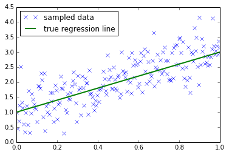

```python
plt.plot(x, y, 'x', label='sampled data')
plt.plot(x, true_regression_line, label='true regression line', lw=2)
plt.legend(loc=0)
```

### Estimating the model

Bayesian 선형 회귀 모형을 위 데이터에 적용한다. **PyMC3**에서 모형은 `with`구문을 통해서 구성한다.

아래 예제에서는 NUTS Sampler를 통해 2000개의 posterior 샘플을 추출한다

```python
with Model() as model:
    ### prior를 설정한다 ###
    sigma = pm.HalfCauchy('sigma', beta=10, testval=1.)
    intercept = pm.Normal('Intercept', 0, sd=20)
    x_coef = pm.Normal('x', 0, sd=20)

    ### Likelihood를 설정한다 ###
    likelihood = pm.Normal('y', mu=intercept + x_coef*x,
                       sd=sigma, observed=y)

    ### posterior를 샘플링한다 ###
    start = pm.find_MAP() # 최적화된 시작지점을 찾는다
    step = pm.NUTS(scaling=start) # 샘플링 알고리즘을 지정한다
    # NUTS 알고리즘을 이용해 2000개의 posterior 샘플을 추출한다
    trace = pm.sample(2000, step, start=start, progressbar=False)
```

```
INFO (theano.gof.compilelock): Refreshing lock /Users/lumiamitie/.theano/compiledir_Darwin-14.5.0-x86_64-i386-64bit-i386-3.5.0-64/lock_dir/lock
INFO:theano.gof.compilelock:Refreshing lock /Users/lumiamitie/.theano/compiledir_Darwin-14.5.0-x86_64-i386-64bit-i386-3.5.0-64/lock_dir/lock
```

```
Applied log-transform to sigma and added transformed sigma_log to model.
```

이 코드는 아주 간단한 선형 모델을 기술하는데도 sigma, intercept, coef를 따로 설정해주어야 했다. 지금은 다루고 있는 모형이 단순하니까 괜찮겠지만, 모형이 더 복잡해지고 변수들 간의 interaction이 포함되는 모델을 구현하려면 식이 너무 복잡해질 우려가 있다. 그렇게 되면 가독성도 떨어지고, 에러를 발생시키기 쉬운 코드가 될 수 있다.

반면에 `glm()` 함수를 사용하게 되면 R의 formula 형태로 모형을 설정할 수 있다. 위와 같은 단순한 선형 모델은 `y ~ x`의 형태로 표현 가능하다.

```python
with Model() as model:
    ### glm()을 통해 모형을 설정한다 ###
    pm.glm.glm('y ~ x', data)

    start = pm.find_MAP()
    step = pm.NUTS(scaling=start)
    trace = pm.sample(2000, step, progressbar=False)
```

```
Applied log-transform to sd and added transformed sd_log to model.
```

`glm`을 통해 모형을 기술할 경우 [Patsy](http://patsy.readthedocs.io/en/latest/quickstart.html) 를 통해서 Design Matrix를 생성하게 된다. 이러한 방식을 통해 같은 모형이더라도 더 짧고 간결하게 표현할 수 있게 된다.

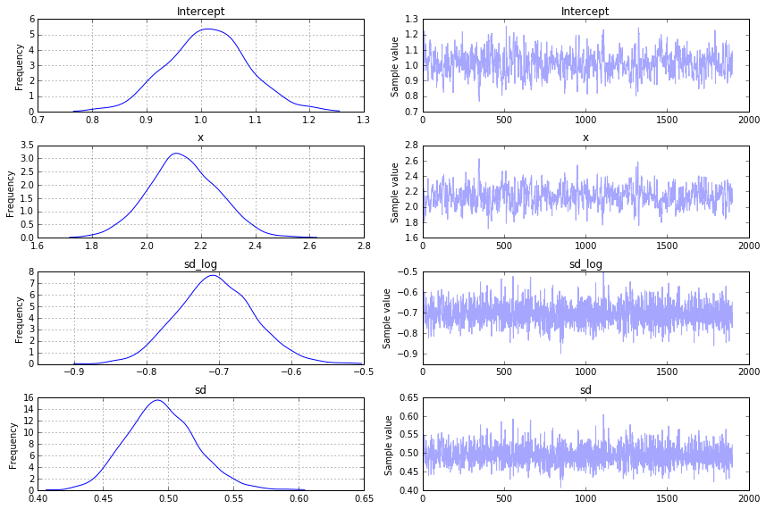

```python
traceplot(trace[100:])
plt.tight_layout()
```

왼쪽의 그래프들은 marginal posterior를 나타낸다. 각 parameter의 값을 x축에 놓고 해당 parameter일 확률값이 y값으로 나타난다. 각 분포에서 확률값이 가장 높은 부분의 parameter값을 잘 살펴보면, 실제값과 비슷한 수치를 나타내고 있다는 것을 확인할 수 있다. 오른쪽의 sampling chain도 특징적인 패턴없이 비교적 안정적인 모양을 보이고 있다.

여기서 우리는 가장 적합한 회귀선 하나를 얻게 되는 것이 아니다. Posterior를 통해 여러 개의 intercept와 slope를 추출하게 된다. 각각의 회귀선을 모두 그래프로 그려볼 수 있다

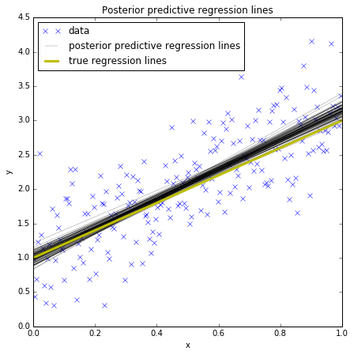

```python
plt.figure(figsize=(7, 7))

plt.plot(x, y, 'x', label='data')
glm.plot_posterior_predictive(trace, samples=100,
                             label='posterior predictive regression lines')
plt.plot(x, true_regression_line, label='true regression lines', lw=3., c='y')

plt.title('Posterior predictive regression lines')
plt.legend(loc=0)
plt.xlabel('x')
plt.ylabel('y')
plt.show()
```

## Bayesian GLM - 2 (Robust Regression)

http://twiecki.github.io/blog/2013/08/27/bayesian-glms-2/

위에서 다루었던 데이터는 사실 잘 만들어진 깔끔한 데이터였다. 실제 데이터는 더 지저분하기 마련이고, 몇 개의 아웃라이어 때문에 정규분포 가정이 소용없어지기도 한다. 아웃라이어가 추가되면 어떻게 되는지 살펴보자!

```python
import theano
```

```python
size = 100
true_intercept = 1
true_slope = 2

x = np.linspace(0, 1, size)
true_regression_line = true_intercept + true_slope * x
y = true_regression_line + np.random.normal(scale=0.5, size=size)

# Outlier 추가
x_out = np.append(x, [0.1, 0.15, 0.2])
y_out = np.append(y, [8, 6, 9])

data = dict(x=x_out, y=y_out)
```

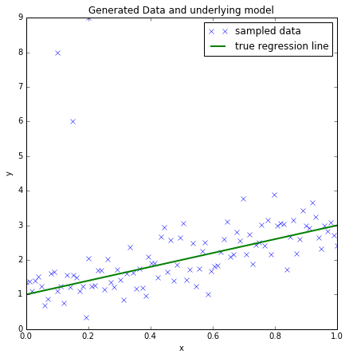

```python
fig = plt.figure(figsize=(7,7))
ax = fig.add_subplot(111, xlabel='x', ylabel='y',
                    title='Generated Data and underlying model')
ax.plot(x_out, y_out, 'x', label='sampled data')
ax.plot(x, true_regression_line, label='true regression line', lw=2.)
plt.legend(loc=0)
```

왼쪽 상단에 세 개의 아웃라이어가 추가되었다

### Robust Regression

이제 동일한 방식으로 linear regression을 진행하면 어떻게 되는지 살펴보자

```python
with pm.Model() as model:
    pm.glm.glm('y ~ x', data)

    start = pm.find_MAP()
    step = pm.NUTS(scaling=start)
    trace = pm.sample(2000, step, progressbar=False)
```

```
INFO (theano.gof.compilelock): Refreshing lock /Users/lumiamitie/.theano/compiledir_Darwin-14.5.0-x86_64-i386-64bit-i386-3.5.0-64/lock_dir/lock
INFO:theano.gof.compilelock:Refreshing lock /Users/lumiamitie/.theano/compiledir_Darwin-14.5.0-x86_64-i386-64bit-i386-3.5.0-64/lock_dir/lock
```

```
Applied log-transform to sd and added transformed sd_log to model.
```

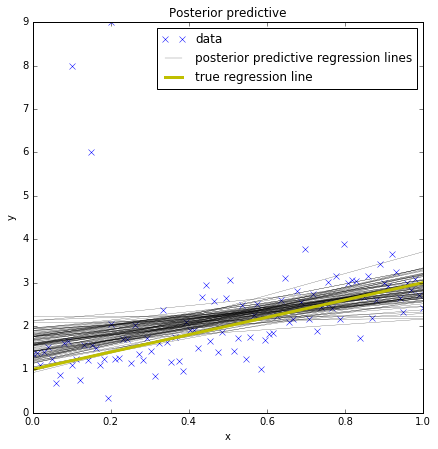

```python
plt.figure(figsize=(7,7))
plt.plot(x_out, y_out, 'x', label='data')
pm.glm.plot_posterior_predictive(trace, samples=100,
                                label='posterior predictive regression lines')
plt.plot(x, true_regression_line,
        label='true regression line', lw=3., c='y')

plt.xlabel('x')
plt.ylabel('y')
plt.legend(loc=0)
plt.show()
```

아웃라이어로 인해 회귀선이 한 쪽으로 치우는 것을 확인할 수 있었다. 정규분포는 꼬리부분에 해당하는 데이터가 나올 확률이 굉장히 낮기 때문에 아웃라이어의 영향을 비교적 강하게 받게된다.

Frequentist라면 Robust Regression을 시행하면 된다. 그러면 Bayesian은 어떤 방법을 취할 수 있을까??

정규분포 대신에 꼬리부분 확률이 더 높은 t분포를 사용해볼 수 있다

우선 정규분포와 t분포가 어떻게 다른지 살펴보자

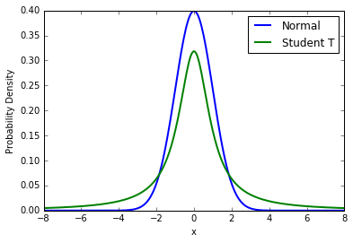

```python
normal_dist = pm.Normal.dist(mu=0, sd=1)
t_dist = pm.StudentT.dist(mu=0, lam=1, nu=1)

x_eval = np.linspace(-8, 8, 300)

plt.plot(x_eval, theano.tensor.exp(normal_dist.logp(x_eval)).eval(),
        label='Normal', lw=2)
plt.plot(x_eval, theano.tensor.exp(t_dist.logp(x_eval)).eval(),
        label='Student T', lw=2)

plt.xlabel('x')
plt.ylabel('Probability Density')
plt.legend()
plt.show()
```

그래프의 양쪽 꼬리를 보면 T분포는 정규분포보다 평균으로부터 멀어질 확률이 더 높다는 것을 확인할 수 있다.

이제 PyMC3에 t분포를 적용해보자

```python
with pm.Model() as model:
    family = pm.glm.families.StudentT()
    pm.glm.glm('y ~ x', data, family=family)

    start = pm.find_MAP()
    step = pm.NUTS(scaling=start)
    trace_robust = pm.sample(2000, step, progressbar=False)
```

```
INFO (theano.gof.compilelock): Refreshing lock /Users/lumiamitie/.theano/compiledir_Darwin-14.5.0-x86_64-i386-64bit-i386-3.5.0-64/lock_dir/lock
INFO:theano.gof.compilelock:Refreshing lock /Users/lumiamitie/.theano/compiledir_Darwin-14.5.0-x86_64-i386-64bit-i386-3.5.0-64/lock_dir/lock
INFO (theano.gof.compilelock): Refreshing lock /Users/lumiamitie/.theano/compiledir_Darwin-14.5.0-x86_64-i386-64bit-i386-3.5.0-64/lock_dir/lock
INFO:theano.gof.compilelock:Refreshing lock /Users/lumiamitie/.theano/compiledir_Darwin-14.5.0-x86_64-i386-64bit-i386-3.5.0-64/lock_dir/lock
```

```
Applied log-transform to lam and added transformed lam_log to model.
```

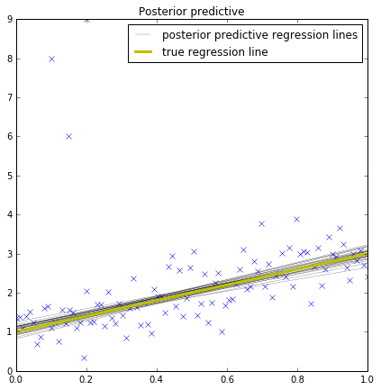

```python
plt.figure(figsize=(7,7))
plt.plot(x_out, y_out, 'x')
pm.glm.plot_posterior_predictive(trace_robust,
                                label='posterior predictive regression lines')
plt.plot(x, true_regression_line,
        label='true regression line', lw=3, c='y')
plt.legend()
plt.show()
```

훨씬 나아졌다

t분포 하에서는 아웃라이어가 등장할 수 있는 확률이 더 높기 때문에 아웃라이어 몇 개만으로 모형에 큰 영향을 주지는 못하는 것을 볼 수 있다.

## Hierarchical Linear Regression

http://twiecki.github.io/blog/2014/03/17/bayesian-glms-3/

Gelman의 [radon 데이터](https://github.com/twiecki/WhileMyMCMCGentlySamples/tree/master/content/downloads/notebooks) 는 hierarchical modeling의 교과서같은 데이터다. 몇몇 주에서 카운티별로 일부 가정의 라돈 가스 검출량을 측정한 결과이다. 일반적으로 라돈은 집 내부의 지하실에 가장 많이 존재하며, 토양의 특성에 따라 자연에 존재하는 정도가 다르다고 알려져있다.

우리는 각 지역별로 전혀 다른 모델을 설정해서 지역간에 유사한 점이 하나도 없다고 가정할 수 있다. 또, 모든 데이터를 하나로 모아서 모든 지역에 동일한 모델을 적용할 수 있다고 주장할 수도 있다. Hierarchical Modelling은 양쪽의 주장을 모두 받아들이면서 모형을 구성할 수 있다. 일단 카운티별로 라돈이 얼마나 다르게 존재하는지 확인하고, 지하실의 유무에 따라서도 차이가 발생하는지 살펴보려고 한다

```python
import pandas as pd
```

```python
radon_data = pd.read_csv('radon.csv')

county_names = radon_data.county.unique()
county_idx = radon_data['county_code'].values
n_counties = len(radon_data.county.unique())
```

```python
radon_data[['county', 'log_radon', 'floor']].head()
```

|  | county | log_radon | floor |
| --- | --- | --- | --- |
| 0 | AITKIN | 0.832909 | 1 |
| 1 | AITKIN | 0.832909 | 0 |
| 2 | AITKIN | 1.098612 | 0 |
| 3 | AITKIN | 0.095310 | 0 |
| 4 | ANOKA | 1.163151 | 0 |

지하실이 존재하는 집은 `floor == 0` 없는 집은 `floor == 1`로 나타난다. 지하실의 존재는 실내 라돈 농도를 상승시키는 효과를 발생시키는가??

### The Models

#### 1. Pooling of Measurements

모든 데이터를 하나의 regression으로 계산하여 단일한 모델을 만들 수 있다. 수학적으로 표현하면 다음과 같은 식이 된다.

$$radon_{i,c} = \alpha + \beta * floor_{i,c} + \epsilon$$

i가 관측대상, c가 카운티, floor는 지하실 존재여부를 나타낸다. 이렇게 계산하면 모든 카운티와 가구들을 대상으로하는 하나의 intercept와 slope를 계산할 수 있다.

#### 2. Unpooled Measurements : Separate Regression

하지만 만약 지역별로 다른 영향이 존재한다면 어떤식으로 분석해야할까? 이 경우에는 카운티별로 서로 다른 regression을 구하는 것이 방법일 수 있겠다. 수식으로는 아래와 같이 표현할 수 있다.

$$radon_{i,c} = \alpha_c + \beta_c * floor_{i,c} + \epsilon_c$$

#### 3. Partial Pooling : Hierarchical Regression

위 두 가지 극단적인 모델의 중간 단계를 취할 수도 있다. $\alpha_c$와 $\beta_c$가 각각 다르지만 유사한 성질을 공유한다고 볼 수 있다. 각각의 parameter가 공통의 분포로부터 나왔다고 가정해보자.

$$\alpha_c \sim N(\mu_{\alpha}, \sigma^2_{\alpha})$$$$\beta_c \sim N(\mu_{\beta}, \sigma^2_{\beta})$$

### Probabilistic Programming

#### Unpooled / non-hierarchical model

아래 코드는 너무 오래걸려서 중간에 stop...

```python
#indiv_traces = {}

#for county_name in county_names:
    # 특정 카운티에 속하는 데이터만 필터링한다
#    c_data = radon_data.ix[radon_data.county == county_name]
#    c_log_radon = c_data.log_radon
#    c_floor_measure = c_data.floor.values

#    with pm.Model() as individual_model:
        # intercept prior
#        a = pm.Normal('alpha', mu=0, sd=100**2)
        # slope prior
#        b = pm.Normal('beta', mu=0, sd=100**2)

        # Model Error Prior
#        eps = pm.Uniform('eps', lower=0, upper=100)

        # Linear Model
#        radon_est = a + b * c_floor_measure

        # Data Likelihood
#        radon_like = pm.Normal('radon_like', mu=radon_est, sd=eps, observed = c_log_radon)

#        step = pm.NUTS()
#        trace = pm.sample(2000, step=step, progressbar=False)

    # 이후의 분석을 위해 데이터를 저장한다
#    indiv_traces[county_name] = trace
```

#### Hierarchical Model

```python
with pm.Model() as hierarchical_model:
    # 그룹별 hyperprior
    mu_a = pm.Normal('mu_alpha', mu=0, sd=100**2)
    sigma_a = pm.Uniform('sigma_alpha', lower=0, upper=100)

    mu_b = pm.Normal('mu_beta', mu=0, sd=100**2)
    sigma_b = pm.Uniform('sigma_beta', lower=0, upper=100)

    # 각 카운티의 intercept (mu_a를 중심으로 분포)
    a = pm.Normal('alpha', mu=mu_a, sd=sigma_a, shape=n_counties)
    # 각 카운티의 slope (mu_b를 중심으로 분포)
    b = pm.Normal('beta', mu=mu_b, sd=sigma_b, shape=n_counties)

    # 모형 error
    eps = pm.Uniform('eps', lower=0, upper=100)

    # 모형을 통한 예측
    radon_est = a[county_idx] + b[county_idx] * radon_data.floor.values

    # 데이터 Likelihood
    radon_like = pm.Normal('radon_like', mu=radon_est, sd=eps, observed=radon_data.log_radon)
```

```
Applied interval-transform to sigma_alpha and added transformed sigma_alpha_interval to model.
Applied interval-transform to sigma_beta and added transformed sigma_beta_interval to model.
```

```
INFO (theano.gof.compilelock): Refreshing lock /Users/lumiamitie/.theano/compiledir_Darwin-14.5.0-x86_64-i386-64bit-i386-3.5.0-64/lock_dir/lock
INFO:theano.gof.compilelock:Refreshing lock /Users/lumiamitie/.theano/compiledir_Darwin-14.5.0-x86_64-i386-64bit-i386-3.5.0-64/lock_dir/lock
```

```
Applied interval-transform to eps and added transformed eps_interval to model.
```

```python
with hierarchical_model:
    start = pm.find_MAP()
    step = pm.NUTS(scaling=start)
    hierarchical_trace = pm.sample(2000, step, start=start, progressbar=False)
```

[output not shown]

[output cut: 187 more lines]

[output not shown]

```
array([[<matplotlib.axes._subplots.AxesSubplot object at 0x1bae32cc0>,
        <matplotlib.axes._subplots.AxesSubplot object at 0x1bc030518>]], dtype=object)
```

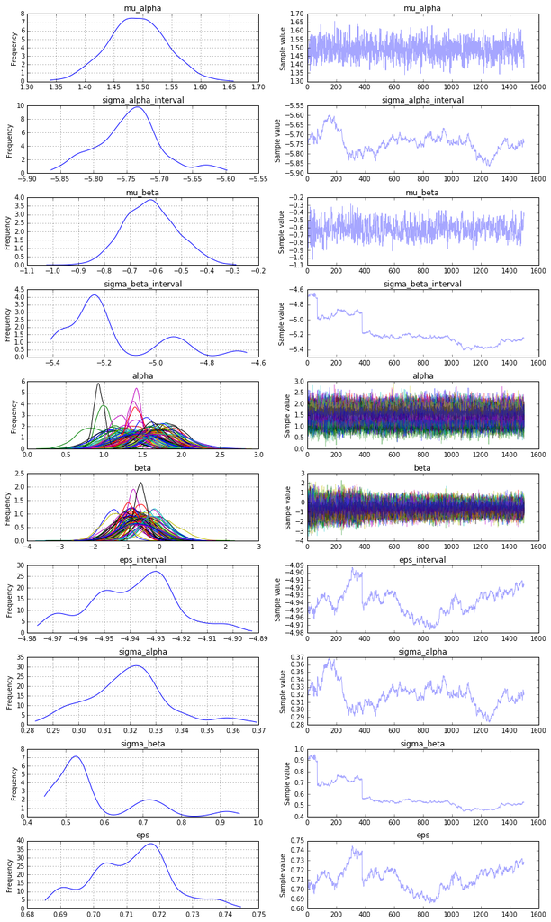

```python
pm.traceplot(hierarchical_trace[500:])
```

`mu_a`는 그룹별 평균(로그)라돈 수치를 나타낸다. `mu_b`는 대부분의 경우 0보다 작은 구간에서 분포하고 있다. 따라서 지하실이 존재하지 않는 경우 라돈 수치가 유의미하게 감소한다는 것을 확인할 수 있다.

### Posterior Predictive Check

#### The Root Mean Square Deviation

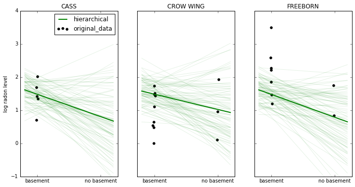

```python
selection = ['CASS', 'CROW WING', 'FREEBORN']
fig, axis = plt.subplots(1, 3, figsize=(12, 6), sharey=True, sharex=True)
axis = axis.ravel()

for i, c in enumerate(selection):
    c_data = radon_data.ix[radon_data.county == c]
    c_data = c_data.reset_index(drop=True)
    z = list(c_data['county_code'])[0]

    xvals = np.linspace(-0.2, 1.2)
    for a_val, b_val in zip(hierarchical_trace['alpha'][500::10][z],
                           hierarchical_trace['beta'][500::10][z]):
        axis[i].plot(xvals, a_val + b_val * xvals, 'g', alpha=0.1)

    axis[i].plot(xvals, hierarchical_trace['alpha'][500::10][z].mean() +
                hierarchical_trace['beta'][500::10][z].mean() * xvals,
                'g', alpha=1, lw=2, label='hierarchical')
    axis[i].scatter(c_data.floor + np.random.randn(len(c_data))*0.01, c_data.log_radon,
                   alpha=1, color='k', marker='.', s=80, label='original_data')

    axis[i].set_xticks([0,1])
    axis[i].set_xticklabels(['basement', 'no basement'])
    axis[i].set_ylim(-1, 4)
    axis[i].set_title(c)

    if not i%3:
        axis[i].legend()
        axis[i].set_ylabel('log radon level')
```

### Shrinkage

Shrinkage란 예측치들이 공통의 분포로 인해 평균 부근으로 모이는 과정을 말한다. 각 parameter들이 그룹 평균에서 멀리 떨어져있을 확률은 매우 낮다. 따라서 조금 더 높은 확률을 가지는 값으로 예측치가 구해지는 경향이 생긴다. Non-hierarchical Model에서는 각 카운티의 정보만 사용하기 때문에 카운티간의 예측치는 멀어질 우려가 있다. 이 경우에는 모형이 아웃라이어에 취약해질 수 있다.